# Diamonds Project

Zachary Guan

November 15, 2018

A detailed anaylsis of the effects of different diamond characteristics on pricing of diamonds.

```r
diamonds <- read.delim("us.carata.txt")

summary(diamonds)
```

```
##      carat        color  clarity   certification     price
##  Min.   :0.1800   D:12   IF  :30   GIA:95        Min.   : 374.0
##  1st Qu.:0.3400   E:30   VS1 :59   HRD:51        1st Qu.: 900.8
##  Median :0.5800   F:51   VS2 :31   IGI:54        Median :2259.0
##  Mean   :0.6134   G:43   VVS1:31                 Mean   :2843.6
##  3rd Qu.:0.8325   H:40   VVS2:49                 3rd Qu.:4226.5
##  Max.   :1.0900   I:24                           Max.   :9389.0
```

## Including Plots

including simple histograms of each category of diamonds

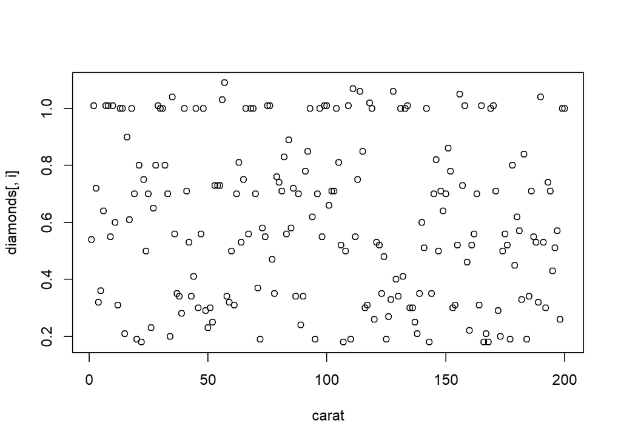

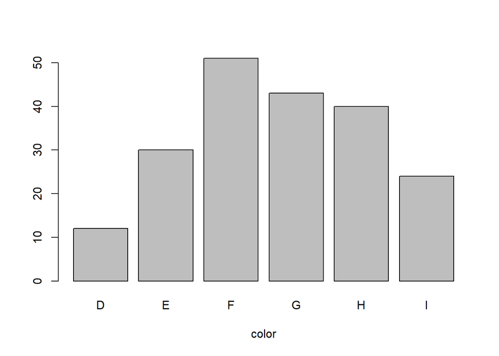

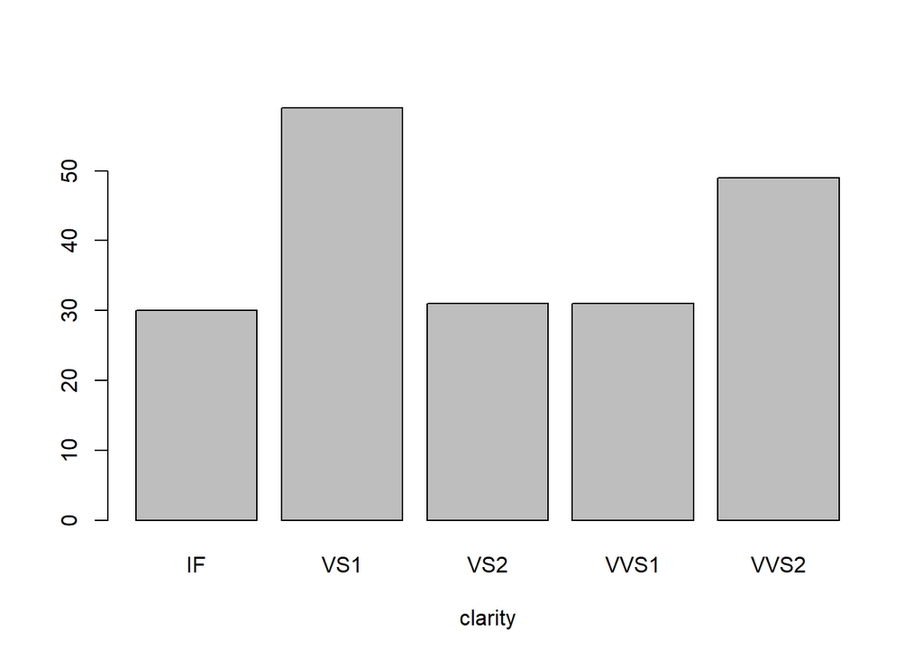

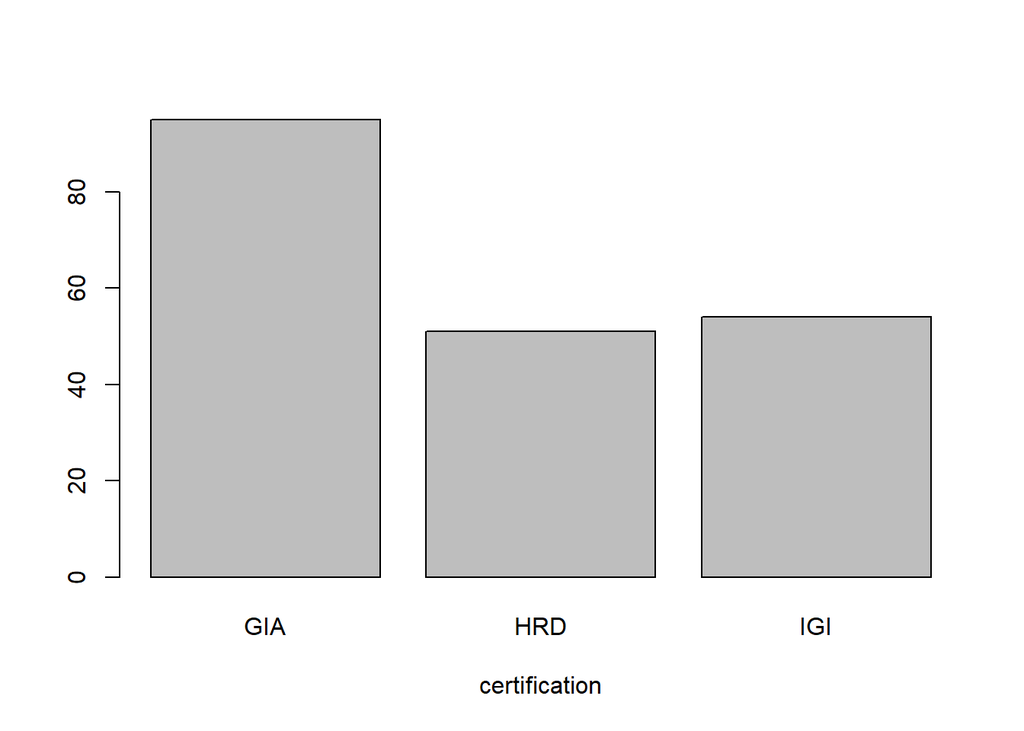

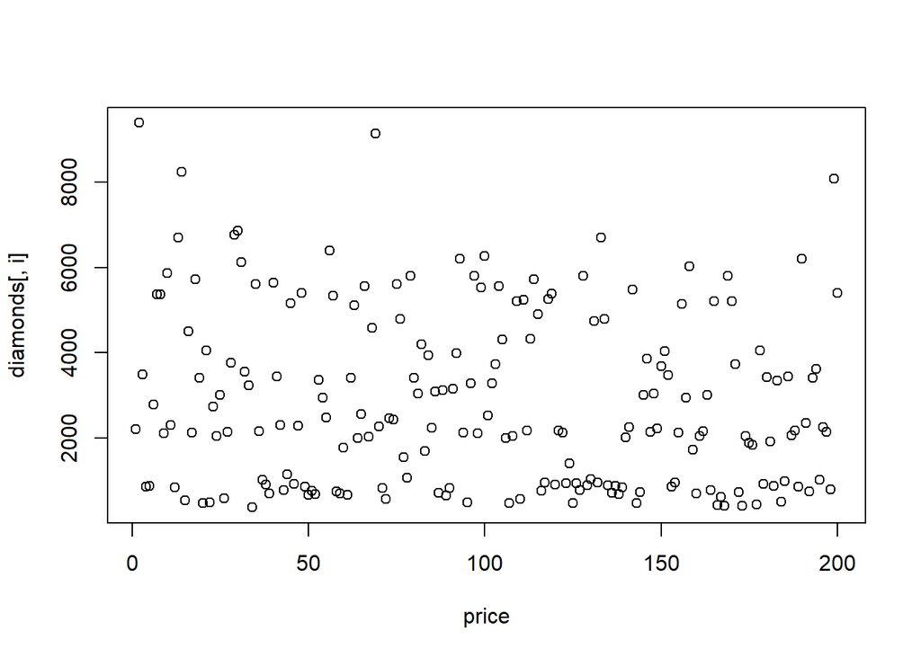

```r
for(i in 1:ncol(diamonds)){
  par(ask = TRUE)
  plot(diamonds[,i], xlab = names(diamonds)[i],)
}
```

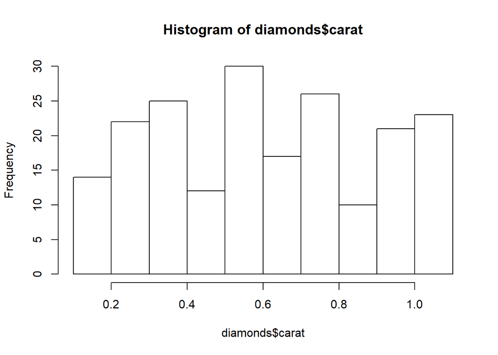

```r
hist(diamonds$carat)
```

Now plotting each variable against price to look for observable correlation or patterns ##weighted least squares or boxcox

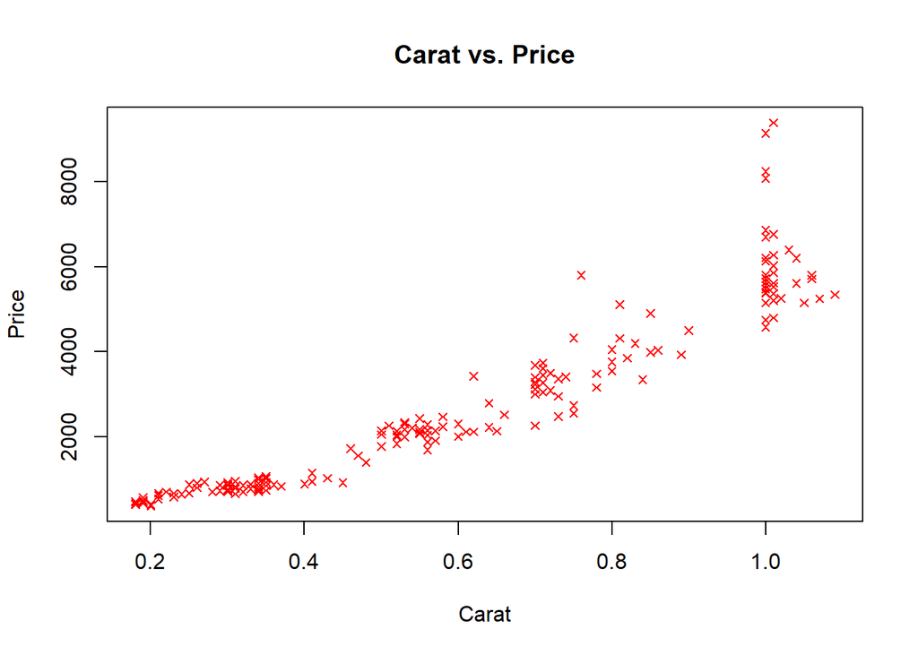

```r
plot(diamonds$carat,diamonds$price, xlab = "Carat",ylab ="Price", main="Carat vs. Price", pch = 4, cex = .80, col = "red")
```

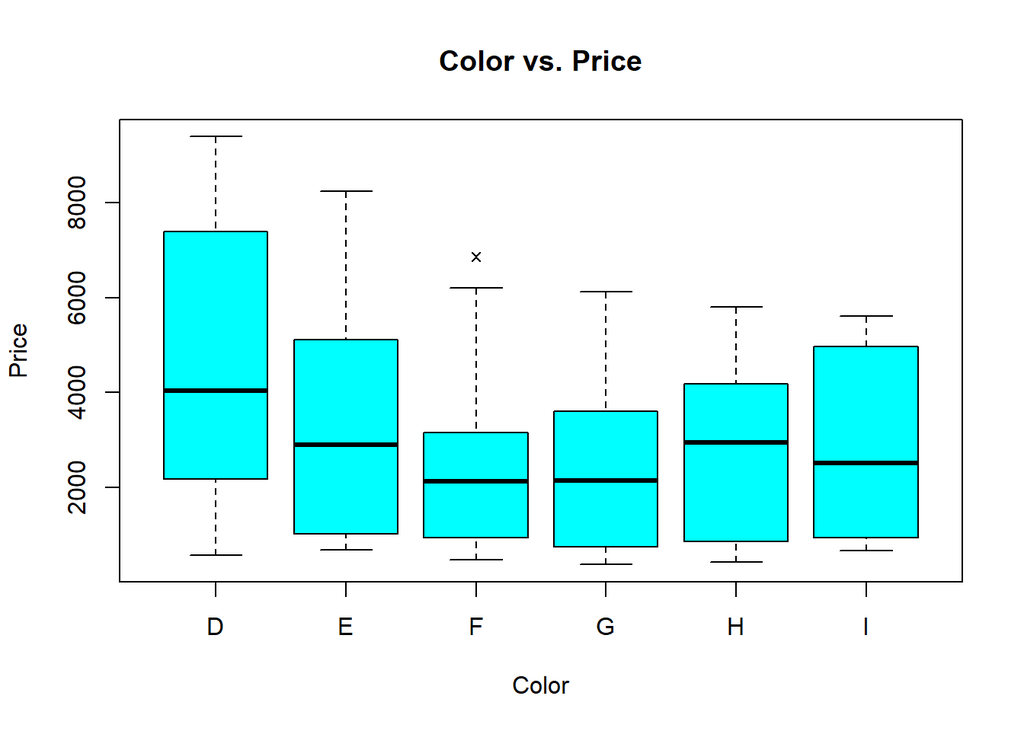

```r
plot(diamonds$color,diamonds$price, xlab = "Color",ylab ="Price", main="Color vs. Price", pch = 4, cex = .80, col = "cyan")
```

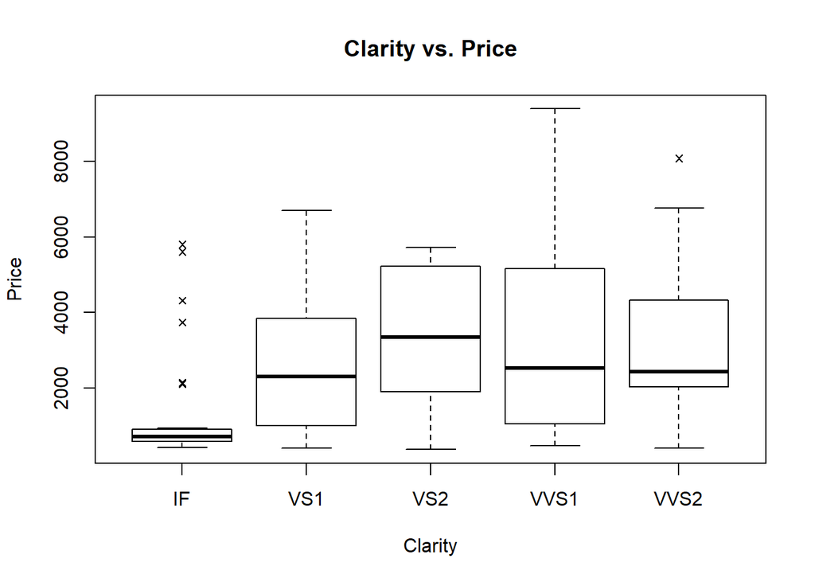

```r
plot(diamonds$clarity,diamonds$price, xlab = "Clarity",ylab ="Price", main="Clarity vs. Price", pch = 4, cex = .80)
```

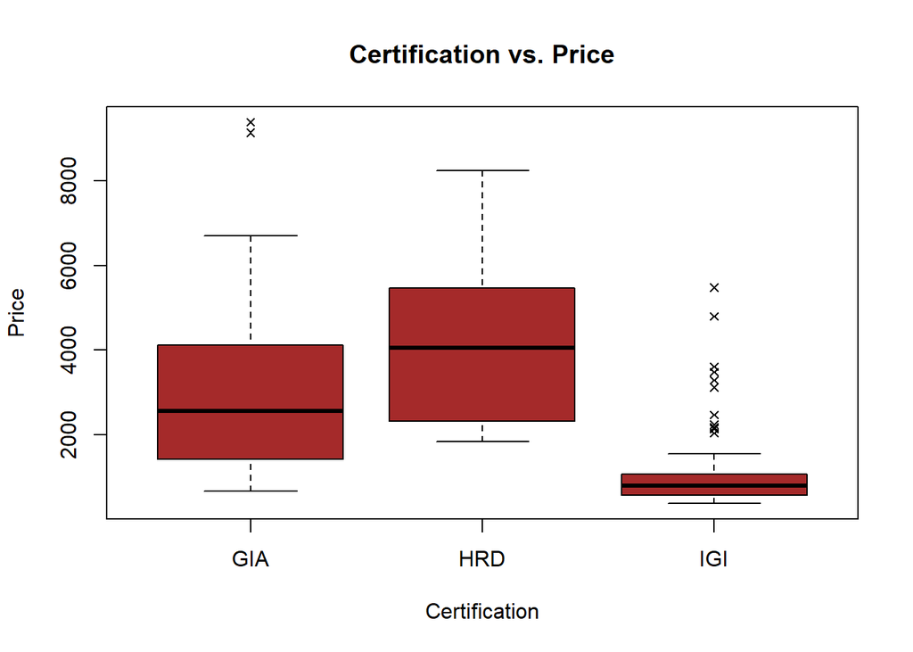

[output not shown]

```r
plot(diamonds$certification,diamonds$price, xlab = "Certification",ylab ="Price", main="Certification vs. Price", pch = 4, cex = .80, col = "brown")
```

Now attempting to experiment with linear regression

```r
all <- lm(price~carat + color  + certification + clarity,data =diamonds )
carat <- lm(price~ carat, data = diamonds)
color <- lm(price~color, data = diamonds)

summary(all)
```

```
##
## Call:
## lm(formula = price ~ carat + color + certification + clarity,
##     data = diamonds)
##
## Residuals:
##    Min     1Q Median     3Q    Max
## -984.9 -245.6  -46.0  186.1 2029.5
##
## Coefficients:
##                  Estimate Std. Error t value Pr(>|t|)
## (Intercept)        150.91     186.72   0.808   0.4200
## carat             7340.60     146.00  50.278  < 2e-16 ***
## colorE            -805.69     149.28  -5.397 2.03e-07 ***
## colorF           -1185.73     141.80  -8.362 1.39e-14 ***
## colorG           -1248.30     143.87  -8.676 1.97e-15 ***
## colorH           -1553.70     145.18 -10.702  < 2e-16 ***
## colorI           -1938.28     154.36 -12.557  < 2e-16 ***
## certificationHRD    20.75      84.54   0.245   0.8064
## certificationIGI    61.12     102.40   0.597   0.5513
## clarityVS1        -825.95     122.06  -6.767 1.64e-10 ***
## clarityVS2        -990.36     135.36  -7.317 7.27e-12 ***
## clarityVVS1       -205.42     121.94  -1.685   0.0937 .
## clarityVVS2       -685.29     114.65  -5.977 1.13e-08 ***
## ---
## Signif. codes:  0 '***' 0.001 '**' 0.01 '*' 0.05 '.' 0.1 ' ' 1
##
## Residual standard error: 431.7 on 187 degrees of freedom
## Multiple R-squared:  0.9576, Adjusted R-squared:  0.9549
## F-statistic: 352.1 on 12 and 187 DF,  p-value: < 2.2e-16
```

```r
summary(carat)
```

```
##
## Call:
## lm(formula = price ~ carat, data = diamonds)
##
## Residuals:
##     Min      1Q  Median      3Q     Max
## -1221.3  -344.6   -74.6   236.3  3840.4
##
## Coefficients:
##             Estimate Std. Error t value Pr(>|t|)
## (Intercept)  -1340.1      114.5  -11.70   <2e-16 ***
## carat         6820.4      169.8   40.17   <2e-16 ***
## ---
## Signif. codes:  0 '***' 0.001 '**' 0.01 '*' 0.05 '.' 0.1 ' ' 1
##
## Residual standard error: 673.7 on 198 degrees of freedom
## Multiple R-squared:  0.8907, Adjusted R-squared:  0.8901
## F-statistic:  1613 on 1 and 198 DF,  p-value: < 2.2e-16
```

```r
summary(color)
```

```
##
## Call:
## lm(formula = price ~ color, data = diamonds)
##
## Residuals:
##    Min     1Q Median     3Q    Max
##  -4137  -1732   -312   1502   4966
##
## Coefficients:
##             Estimate Std. Error t value Pr(>|t|)
## (Intercept)   4704.3      571.0   8.239 2.54e-14 ***
## colorE       -1429.2      675.6  -2.116 0.035659 *
## colorF       -2342.9      634.6  -3.692 0.000289 ***
## colorG       -2147.7      645.7  -3.326 0.001054 **
## colorH       -1917.0      651.0  -2.945 0.003627 **
## colorI       -1697.3      699.3  -2.427 0.016126 *
## ---
## Signif. codes:  0 '***' 0.001 '**' 0.01 '*' 0.05 '.' 0.1 ' ' 1
##
## Residual standard error: 1978 on 194 degrees of freedom
## Multiple R-squared:  0.07699,    Adjusted R-squared:  0.0532
## F-statistic: 3.236 on 5 and 194 DF,  p-value: 0.007882
```

```r
interaction_cert <- lm(price~carat*certification + color + clarity, data = diamonds)

int_<-lm(price~ carat + color:certification + clarity, data = diamonds)

int_ccl <- lm(price ~ carat + color + clarity:certification, data= diamonds)

int_carlt <-lm(price ~ carat:clarity + color, data = diamonds)

summary(interaction_cert)
```

```
##
## Call:
## lm(formula = price ~ carat * certification + color + clarity,
##     data = diamonds)
##
## Residuals:
##    Min     1Q Median     3Q    Max
## -923.1 -220.3  -65.9  170.5 2030.0
##
## Coefficients:
##                        Estimate Std. Error t value Pr(>|t|)
## (Intercept)              -14.07     202.10  -0.070 0.944576
## carat                   7364.38     172.84  42.609  < 2e-16 ***
## certificationHRD       -1020.46     289.50  -3.525 0.000534 ***
## certificationIGI         557.30     193.15   2.885 0.004374 **
## colorE                  -855.45     137.70  -6.212 3.37e-09 ***
## colorF                 -1165.43     130.70  -8.917 4.58e-16 ***
## colorG                 -1230.23     132.42  -9.291  < 2e-16 ***
## colorH                 -1540.08     133.67 -11.522  < 2e-16 ***
## colorI                 -1935.38     142.10 -13.620  < 2e-16 ***
## clarityVS1              -665.92     121.58  -5.477 1.39e-07 ***
## clarityVS2              -857.33     129.09  -6.642 3.35e-10 ***
## clarityVVS1              -64.95     116.40  -0.558 0.577530
## clarityVVS2             -520.70     112.68  -4.621 7.14e-06 ***
## carat:certificationHRD  1261.98     352.72   3.578 0.000442 ***
## carat:certificationIGI -1239.85     343.60  -3.608 0.000396 ***
## ---
## Signif. codes:  0 '***' 0.001 '**' 0.01 '*' 0.05 '.' 0.1 ' ' 1
##
## Residual standard error: 397.2 on 185 degrees of freedom
## Multiple R-squared:  0.9645, Adjusted R-squared:  0.9618
## F-statistic:   359 on 14 and 185 DF,  p-value: < 2.2e-16
```

```r
summary(int_)
```

```
##
## Call:
## lm(formula = price ~ carat + color:certification + clarity, data = diamonds)
##
## Residuals:
##      Min       1Q   Median       3Q      Max
## -1001.75  -197.00   -22.64   181.12  2052.95
##
## Coefficients: (1 not defined because of singularities)
##                         Estimate Std. Error t value Pr(>|t|)
## (Intercept)             -1535.23     175.64  -8.741 1.74e-15 ***
## carat                    7219.66     138.14  52.262  < 2e-16 ***
## clarityVS1               -725.06     117.96  -6.147 5.10e-09 ***
## clarityVS2               -866.33     129.59  -6.685 2.90e-10 ***
## clarityVVS1              -116.66     116.81  -0.999 0.319279
## clarityVVS2              -619.92     110.45  -5.613 7.58e-08 ***
## colorD:certificationGIA  1696.09     221.03   7.674 1.08e-12 ***
## colorE:certificationGIA   694.53     202.93   3.423 0.000771 ***
## colorF:certificationGIA   548.37     199.14   2.754 0.006509 **
## colorG:certificationGIA   483.93     206.23   2.346 0.020058 *
## colorH:certificationGIA   151.78     203.27   0.747 0.456248
## colorI:certificationGIA  -274.64     215.32  -1.276 0.203793
## colorD:certificationHRD  3014.49     445.90   6.761 1.92e-10 ***
## colorE:certificationHRD  1446.35     239.51   6.039 8.91e-09 ***
## colorF:certificationHRD   412.23     216.28   1.906 0.058265 .
## colorG:certificationHRD   374.14     218.63   1.711 0.088778 .
## colorH:certificationHRD    26.39     207.18   0.127 0.898786
## colorI:certificationHRD  -298.85     239.37  -1.248 0.213499
## colorD:certificationIGI  1048.87     335.78   3.124 0.002087 **
## colorE:certificationIGI   782.83     262.63   2.981 0.003280 **
## colorF:certificationIGI   508.88     194.79   2.612 0.009762 **
## colorG:certificationIGI   491.26     192.90   2.547 0.011727 *
## colorH:certificationIGI   420.06     217.83   1.928 0.055405 .
## colorI:certificationIGI       NA         NA      NA       NA
## ---
## Signif. codes:  0 '***' 0.001 '**' 0.01 '*' 0.05 '.' 0.1 ' ' 1
##
## Residual standard error: 400.6 on 177 degrees of freedom
## Multiple R-squared:  0.9655, Adjusted R-squared:  0.9612
## F-statistic: 224.8 on 22 and 177 DF,  p-value: < 2.2e-16
```

```r
summary(int_ccl)
```

```
##
## Call:
## lm(formula = price ~ carat + color + clarity:certification, data = diamonds)
##
## Residuals:
##      Min       1Q   Median       3Q      Max
## -1033.87  -219.99   -42.41   184.66  1811.17
##
## Coefficients: (1 not defined because of singularities)
##                              Estimate Std. Error t value Pr(>|t|)
## (Intercept)                   -506.40     187.23  -2.705 0.007497 **
## carat                         7360.94     146.74  50.165  < 2e-16 ***
## colorE                        -781.51     149.24  -5.237 4.55e-07 ***
## colorF                       -1111.38     142.98  -7.773 5.79e-13 ***
## colorG                       -1210.26     144.22  -8.392 1.41e-14 ***
## colorH                       -1498.52     145.53 -10.297  < 2e-16 ***
## colorI                       -1890.53     153.69 -12.301  < 2e-16 ***
## clarityIF:certificationGIA     377.01     278.91   1.352 0.178172
## clarityVS1:certificationGIA   -222.31     138.42  -1.606 0.110017
## clarityVS2:certificationGIA   -398.63     156.02  -2.555 0.011452 *
## clarityVVS1:certificationGIA   830.53     218.16   3.807 0.000193 ***
## clarityVVS2:certificationGIA  -190.47     158.42  -1.202 0.230844
## clarityIF:certificationHRD     292.47     324.97   0.900 0.369325
## clarityVS1:certificationHRD   -174.00     195.30  -0.891 0.374156
## clarityVS2:certificationHRD   -475.22     193.99  -2.450 0.015261 *
## clarityVVS1:certificationHRD   356.79     175.96   2.028 0.044072 *
## clarityVVS2:certificationHRD    25.97     165.57   0.157 0.875524
## clarityIF:certificationIGI     715.47     152.26   4.699 5.20e-06 ***
## clarityVS1:certificationIGI   -302.37     245.36  -1.232 0.219425
## clarityVS2:certificationIGI    618.47     441.40   1.401 0.162899
## clarityVVS1:certificationIGI   283.21     174.34   1.624 0.106032
## clarityVVS2:certificationIGI       NA         NA      NA       NA
## ---
## Signif. codes:  0 '***' 0.001 '**' 0.01 '*' 0.05 '.' 0.1 ' ' 1
##
## Residual standard error: 419.6 on 179 degrees of freedom
## Multiple R-squared:  0.9617, Adjusted R-squared:  0.9574
## F-statistic: 224.6 on 20 and 179 DF,  p-value: < 2.2e-16
```

```r
summary(int_carlt)
```

```
##
## Call:
## lm(formula = price ~ carat:clarity + color, data = diamonds)
##
## Residuals:
##      Min       1Q   Median       3Q      Max
## -1027.04  -278.62   -66.27   274.82  1876.62
##
## Coefficients:
##                   Estimate Std. Error t value Pr(>|t|)
## (Intercept)         -382.7      158.3  -2.417   0.0166 *
## colorE              -734.9      155.1  -4.738 4.24e-06 ***
## colorF             -1070.1      147.0  -7.279 8.77e-12 ***
## colorG             -1142.9      149.0  -7.669 8.90e-13 ***
## colorH             -1434.9      149.1  -9.623  < 2e-16 ***
## colorI             -1813.9      159.8 -11.351  < 2e-16 ***
## carat:clarityIF     8159.5      276.4  29.522  < 2e-16 ***
## carat:clarityVS1    6783.0      143.8  47.159  < 2e-16 ***
## carat:clarityVS2    6647.6      144.3  46.067  < 2e-16 ***
## carat:clarityVVS1   7816.9      161.5  48.396  < 2e-16 ***
## carat:clarityVVS2   7046.0      143.6  49.073  < 2e-16 ***
## ---
## Signif. codes:  0 '***' 0.001 '**' 0.01 '*' 0.05 '.' 0.1 ' ' 1
##
## Residual standard error: 450.4 on 189 degrees of freedom
## Multiple R-squared:  0.9534, Adjusted R-squared:  0.9509
## F-statistic: 386.3 on 10 and 189 DF,  p-value: < 2.2e-16
```

regsubsets is essentially an automated function of the forward selection I calculated below. This is just another measure to ensure the full model selected is a good fit for the diamond data. The two factors used to check the fit of the model were: Mallow’s Cp and Adjusted R-Squared. Decided that certification was not a good fit for the data based off the anova and the plots from regsubsets. created an interaction between carat and clarity and r-squared is promising. As calarity is not significant when conducted with as.numeric(), therefore interaction was used since clarity and carat have some affects on each other. Using contrasts is tricky, as we cannot conduct any linear trends or deduce which factor is signifcant.

```r
require(leaps)
```

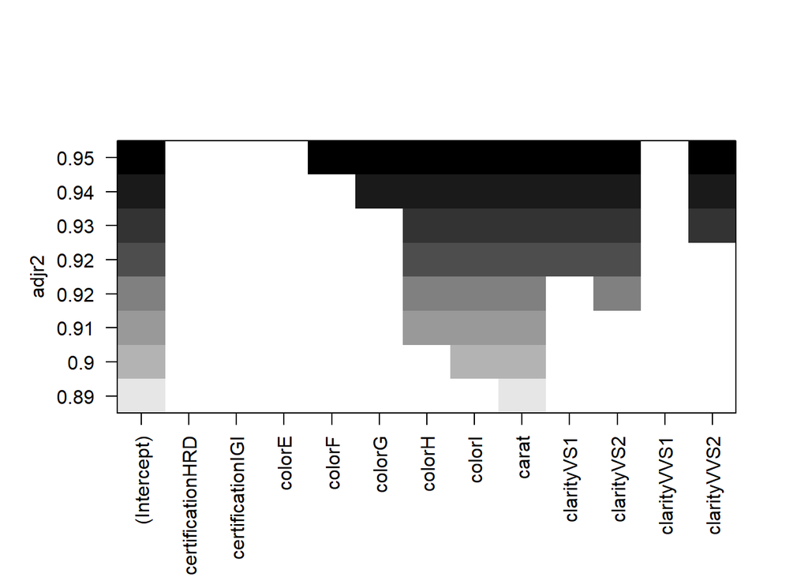

```r
regset = regsubsets(price ~ certification + color + carat + clarity, data = diamonds, method = "forward")

plot(regset,scale="adjr2")
```

```r
###model added interaction between color and carat. Did this based off the boxplot,since the relationship between color and price was pretty random
subset_model1<-lm(price~carat+clarity + color, data = diamonds)
subset_model<-lm(price~carat+clarity + color+certification, data = diamonds)

anova(subset_model1,subset_model)
```

```
## Analysis of Variance Table
##
## Model 1: price ~ carat + clarity + color
## Model 2: price ~ carat + clarity + color + certification
##   Res.Df      RSS Df Sum of Sq      F Pr(>F)
## 1    189 34917806
## 2    187 34849805  2     68001 0.1824 0.8334
```

```r
summary(subset_model)
```

```
##
## Call:
## lm(formula = price ~ carat + clarity + color + certification,
##     data = diamonds)
##
## Residuals:
##    Min     1Q Median     3Q    Max
## -984.9 -245.6  -46.0  186.1 2029.5
##
## Coefficients:
##                  Estimate Std. Error t value Pr(>|t|)
## (Intercept)        150.91     186.72   0.808   0.4200
## carat             7340.60     146.00  50.278  < 2e-16 ***
## clarityVS1        -825.95     122.06  -6.767 1.64e-10 ***
## clarityVS2        -990.36     135.36  -7.317 7.27e-12 ***
## clarityVVS1       -205.42     121.94  -1.685   0.0937 .
## clarityVVS2       -685.29     114.65  -5.977 1.13e-08 ***
## colorE            -805.69     149.28  -5.397 2.03e-07 ***
## colorF           -1185.73     141.80  -8.362 1.39e-14 ***
## colorG           -1248.30     143.87  -8.676 1.97e-15 ***
## colorH           -1553.70     145.18 -10.702  < 2e-16 ***
## colorI           -1938.28     154.36 -12.557  < 2e-16 ***
## certificationHRD    20.75      84.54   0.245   0.8064
## certificationIGI    61.12     102.40   0.597   0.5513
## ---
## Signif. codes:  0 '***' 0.001 '**' 0.01 '*' 0.05 '.' 0.1 ' ' 1
##
## Residual standard error: 431.7 on 187 degrees of freedom
## Multiple R-squared:  0.9576, Adjusted R-squared:  0.9549
## F-statistic: 352.1 on 12 and 187 DF,  p-value: < 2.2e-16
```

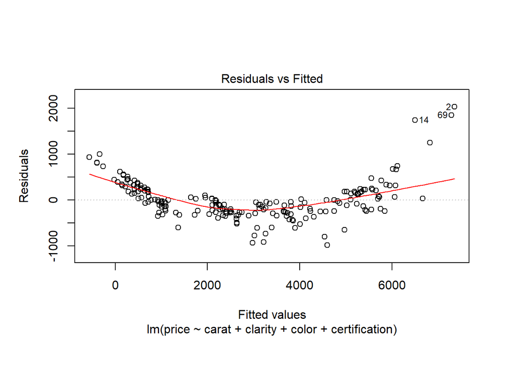

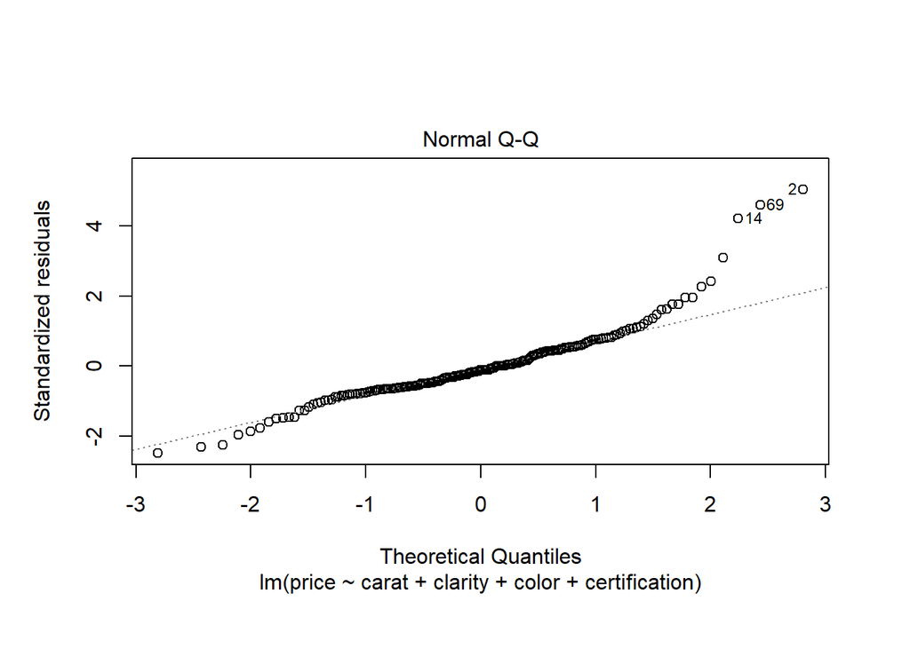

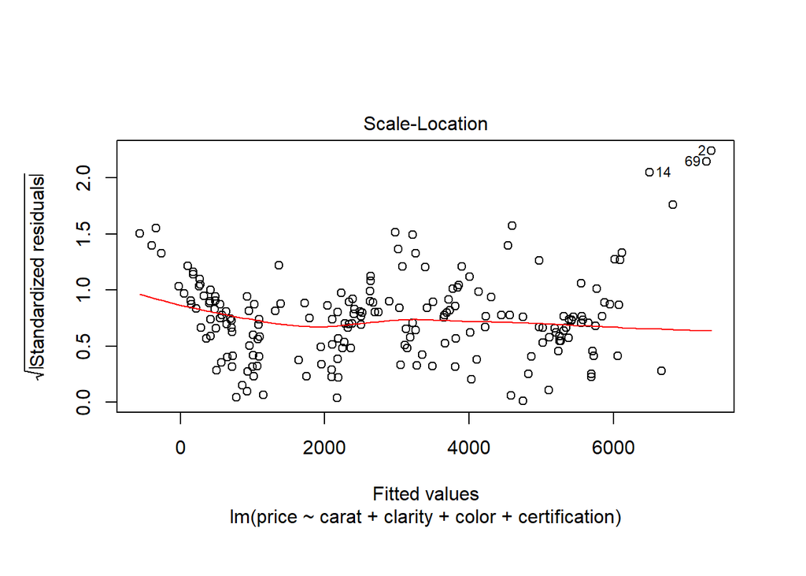

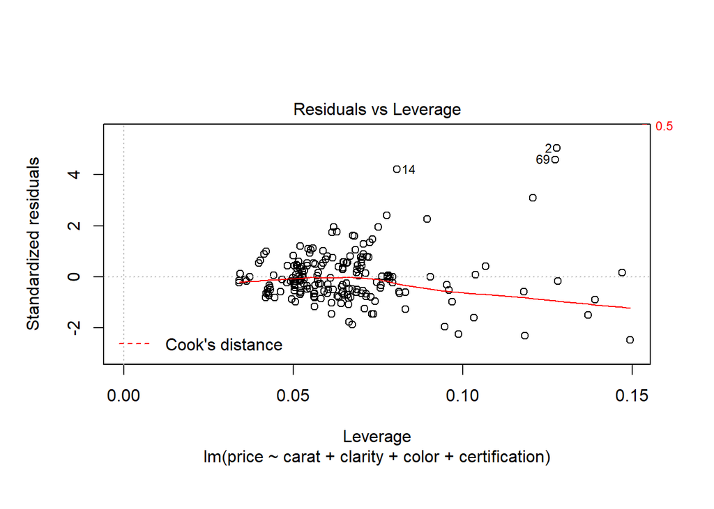

```r
plot(subset_model)
```

```r
v1<-lm(price~carat, data = diamonds)
v2<-lm(price~carat +color, data = diamonds)
v3<-lm(price~carat +color+ certification, data= diamonds)
full_model<-lm(price~carat + color+ certification + clarity, data= diamonds)


pred<-predict(full_model)
summary(v1)
```

```
##
## Call:
## lm(formula = price ~ carat, data = diamonds)
##
## Residuals:
##     Min      1Q  Median      3Q     Max
## -1221.3  -344.6   -74.6   236.3  3840.4
##
## Coefficients:
##             Estimate Std. Error t value Pr(>|t|)
## (Intercept)  -1340.1      114.5  -11.70   <2e-16 ***
## carat         6820.4      169.8   40.17   <2e-16 ***
## ---
## Signif. codes:  0 '***' 0.001 '**' 0.01 '*' 0.05 '.' 0.1 ' ' 1
##
## Residual standard error: 673.7 on 198 degrees of freedom
## Multiple R-squared:  0.8907, Adjusted R-squared:  0.8901
## F-statistic:  1613 on 1 and 198 DF,  p-value: < 2.2e-16
```

```r
summary(v2)
```

```
##
## Call:
## lm(formula = price ~ carat + color, data = diamonds)
##
## Residuals:
##      Min       1Q   Median       3Q      Max
## -1377.10  -339.68   -91.82   301.72  2604.51
##
## Coefficients:
##             Estimate Std. Error t value Pr(>|t|)
## (Intercept)   -142.0      185.3  -0.766    0.444
## carat         6857.9      140.3  48.870  < 2e-16 ***
## colorE        -894.3      185.5  -4.820 2.90e-06 ***
## colorF       -1197.2      175.5  -6.820 1.14e-10 ***
## colorG       -1213.6      178.1  -6.816 1.17e-10 ***
## colorH       -1509.5      178.7  -8.449 7.04e-15 ***
## colorI       -1823.1      191.7  -9.509  < 2e-16 ***
## ---
## Signif. codes:  0 '***' 0.001 '**' 0.01 '*' 0.05 '.' 0.1 ' ' 1
##
## Residual standard error: 542.2 on 193 degrees of freedom
## Multiple R-squared:  0.931,  Adjusted R-squared:  0.9288
## F-statistic: 433.9 on 6 and 193 DF,  p-value: < 2.2e-16
```

```r
summary(v3)
```

```
##
## Call:
## lm(formula = price ~ carat + color + certification, data = diamonds)
##
## Residuals:
##      Min       1Q   Median       3Q      Max
## -1523.15  -271.36   -20.39   249.13  2607.61
##
## Coefficients:
##                  Estimate Std. Error t value Pr(>|t|)
## (Intercept)       -472.26     194.37  -2.430   0.0160 *
## carat             7181.83     168.81  42.543  < 2e-16 ***
## colorE            -881.66     175.95  -5.011 1.23e-06 ***
## colorF           -1254.14     167.03  -7.508 2.23e-12 ***
## colorG           -1315.47     169.84  -7.745 5.45e-13 ***
## colorH           -1564.88     171.15  -9.143  < 2e-16 ***
## colorI           -1912.60     181.97 -10.511  < 2e-16 ***
## certificationHRD   197.57      94.65   2.087   0.0382 *
## certificationIGI   509.31     102.41   4.973 1.46e-06 ***
## ---
## Signif. codes:  0 '***' 0.001 '**' 0.01 '*' 0.05 '.' 0.1 ' ' 1
##
## Residual standard error: 510.7 on 191 degrees of freedom
## Multiple R-squared:  0.9394, Adjusted R-squared:  0.9369
## F-statistic: 370.2 on 8 and 191 DF,  p-value: < 2.2e-16
```

```r
summary(full_model)
```

```
##
## Call:
## lm(formula = price ~ carat + color + certification + clarity,
##     data = diamonds)
##
## Residuals:
##    Min     1Q Median     3Q    Max
## -984.9 -245.6  -46.0  186.1 2029.5
##
## Coefficients:
##                  Estimate Std. Error t value Pr(>|t|)
## (Intercept)        150.91     186.72   0.808   0.4200
## carat             7340.60     146.00  50.278  < 2e-16 ***
## colorE            -805.69     149.28  -5.397 2.03e-07 ***
## colorF           -1185.73     141.80  -8.362 1.39e-14 ***
## colorG           -1248.30     143.87  -8.676 1.97e-15 ***
## colorH           -1553.70     145.18 -10.702  < 2e-16 ***
## colorI           -1938.28     154.36 -12.557  < 2e-16 ***
## certificationHRD    20.75      84.54   0.245   0.8064
## certificationIGI    61.12     102.40   0.597   0.5513
## clarityVS1        -825.95     122.06  -6.767 1.64e-10 ***
## clarityVS2        -990.36     135.36  -7.317 7.27e-12 ***
## clarityVVS1       -205.42     121.94  -1.685   0.0937 .
## clarityVVS2       -685.29     114.65  -5.977 1.13e-08 ***
## ---
## Signif. codes:  0 '***' 0.001 '**' 0.01 '*' 0.05 '.' 0.1 ' ' 1
##
## Residual standard error: 431.7 on 187 degrees of freedom
## Multiple R-squared:  0.9576, Adjusted R-squared:  0.9549
## F-statistic: 352.1 on 12 and 187 DF,  p-value: < 2.2e-16
```

Revising the model

```r
require(car)
revised_model<-lm(price~carat:clarity + color + certification,contrasts = list(color = contr.treatment(n = 6, base =6)), data = diamonds)
rev_mod <-lm(price~carat:clarity + color:carat, data = diamonds)
mod1<-lm(price~ carat:clarity + color+ certification,contrasts = list(certification = contr.treatment(n = 3, base =2)) , data = diamonds)

summary(rev_mod)
```

```
##
## Call:
## lm(formula = price ~ carat:clarity + color:carat, data = diamonds)
##
## Residuals:
##     Min      1Q  Median      3Q     Max
## -942.01 -257.79  -68.32  296.01 1312.79
##
## Coefficients:
##                   Estimate Std. Error t value Pr(>|t|)
## (Intercept)       -1505.58      71.71 -20.995  < 2e-16 ***
## carat:clarityIF    9842.36     268.27  36.688  < 2e-16 ***
## carat:clarityVS1   8536.05     183.29  46.571  < 2e-16 ***
## carat:clarityVS2   8466.82     192.80  43.915  < 2e-16 ***
## carat:clarityVVS1  9523.29     188.60  50.494  < 2e-16 ***
## carat:clarityVVS2  8843.41     186.49  47.421  < 2e-16 ***
## carat:colorE      -1089.50     184.10  -5.918 1.51e-08 ***
## carat:colorF      -1709.13     179.97  -9.497  < 2e-16 ***
## carat:colorG      -1881.32     178.86 -10.518  < 2e-16 ***
## carat:colorH      -2237.03     174.74 -12.802  < 2e-16 ***
## carat:colorI      -2692.77     181.41 -14.844  < 2e-16 ***
## ---
## Signif. codes:  0 '***' 0.001 '**' 0.01 '*' 0.05 '.' 0.1 ' ' 1
##
## Residual standard error: 389.9 on 189 degrees of freedom
## Multiple R-squared:  0.9651, Adjusted R-squared:  0.9632
## F-statistic:   522 on 10 and 189 DF,  p-value: < 2.2e-16
```

```r
summary(mod1)
```

```
##
## Call:
## lm(formula = price ~ carat:clarity + color + certification, data = diamonds,
##     contrasts = list(certification = contr.treatment(n = 3, base = 2)))
##
## Residuals:
##      Min       1Q   Median       3Q      Max
## -1113.05  -241.87   -55.87   259.94  1891.28
##
## Coefficients:
##                   Estimate Std. Error t value Pr(>|t|)
## (Intercept)        -568.59     199.03  -2.857  0.00476 **
## colorE             -724.28     152.64  -4.745 4.13e-06 ***
## colorF            -1095.47     145.51  -7.528 2.11e-12 ***
## colorG            -1185.22     147.48  -8.036 1.02e-13 ***
## colorH            -1439.68     148.37  -9.703  < 2e-16 ***
## colorI            -1845.69     157.21 -11.740  < 2e-16 ***
## certification1      -27.59      85.53  -0.323  0.74732
## certification3      283.81     112.13   2.531  0.01219 *
## carat:clarityIF    8239.64     275.98  29.856  < 2e-16 ***
## carat:clarityVS1   7057.50     165.55  42.631  < 2e-16 ***
## carat:clarityVS2   6916.67     166.64  41.506  < 2e-16 ***
## carat:clarityVVS1  8013.76     183.05  43.779  < 2e-16 ***
## carat:clarityVVS2  7264.78     165.49  43.898  < 2e-16 ***
## ---
## Signif. codes:  0 '***' 0.001 '**' 0.01 '*' 0.05 '.' 0.1 ' ' 1
##
## Residual standard error: 439.5 on 187 degrees of freedom
## Multiple R-squared:  0.9561, Adjusted R-squared:  0.9533
## F-statistic: 339.2 on 12 and 187 DF,  p-value: < 2.2e-16
```

```r
summary(revised_model)
```

```
##
## Call:
## lm(formula = price ~ carat:clarity + color + certification, data = diamonds,
##     contrasts = list(color = contr.treatment(n = 6, base = 6)))
##
## Residuals:
##      Min       1Q   Median       3Q      Max
## -1113.05  -241.87   -55.87   259.94  1891.28
##
## Coefficients:
##                   Estimate Std. Error t value Pr(>|t|)
## (Intercept)       -2441.87     147.98 -16.501  < 2e-16 ***
## color1             1845.69     157.21  11.740  < 2e-16 ***
## color2             1121.41     123.62   9.071  < 2e-16 ***
## color3              750.22     113.85   6.589 4.37e-10 ***
## color4              660.47     114.84   5.751 3.56e-08 ***
## color5              406.01     115.08   3.528 0.000527 ***
## certificationHRD     27.59      85.53   0.323 0.747321
## certificationIGI    311.41      92.20   3.378 0.000890 ***
## carat:clarityIF    8239.64     275.98  29.856  < 2e-16 ***
## carat:clarityVS1   7057.50     165.55  42.631  < 2e-16 ***
## carat:clarityVS2   6916.67     166.64  41.506  < 2e-16 ***
## carat:clarityVVS1  8013.76     183.05  43.779  < 2e-16 ***
## carat:clarityVVS2  7264.78     165.49  43.898  < 2e-16 ***
## ---
## Signif. codes:  0 '***' 0.001 '**' 0.01 '*' 0.05 '.' 0.1 ' ' 1
##
## Residual standard error: 439.5 on 187 degrees of freedom
## Multiple R-squared:  0.9561, Adjusted R-squared:  0.9533
## F-statistic: 339.2 on 12 and 187 DF,  p-value: < 2.2e-16
```

```r
anova(mod1)
```

```
## Analysis of Variance Table
##
## Response: price
##                Df    Sum Sq   Mean Sq F value    Pr(>F)
## color           5  63299848  12659970  65.548 < 2.2e-16 ***
## certification   2 237052426 118526213 613.678 < 2.2e-16 ***
## carat:clarity   5 485730367  97146073 502.981 < 2.2e-16 ***
## Residuals     187  36117319    193141
## ---
## Signif. codes:  0 '***' 0.001 '**' 0.01 '*' 0.05 '.' 0.1 ' ' 1
```

```r
vif(revised_model)
```

```
##                   GVIF Df GVIF^(1/(2*Df))
## color         1.268004  5        1.024029
## certification 2.088340  2        1.202127
## carat:clarity 2.277562  5        1.085793
```

```r
vif(rev_mod)
```

```
##                   GVIF Df GVIF^(1/(2*Df))
## carat:clarity 3.536848  5        1.134649
## carat:color   3.536848  5        1.134649
```

check if the current final model is good; evident that final linear model is still not a great fit. Residual has a distinct pattern, therefore assume non-linear regression needed. The The residual had very big variance towards large diamonds and the residual was non-linear, two important observations. Y needs to be adjusted.

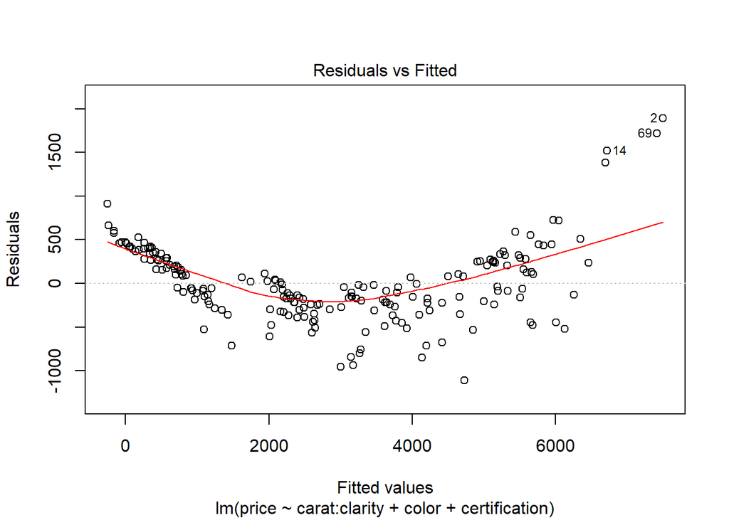

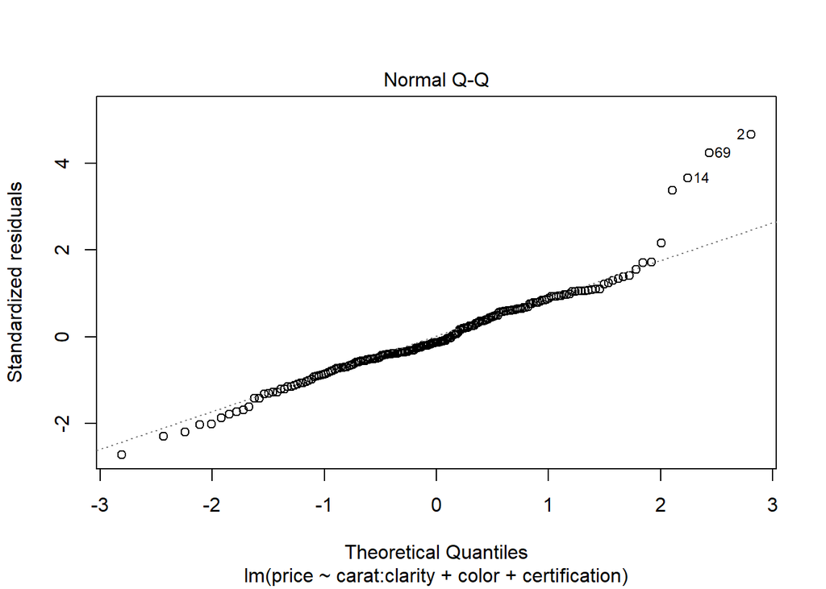

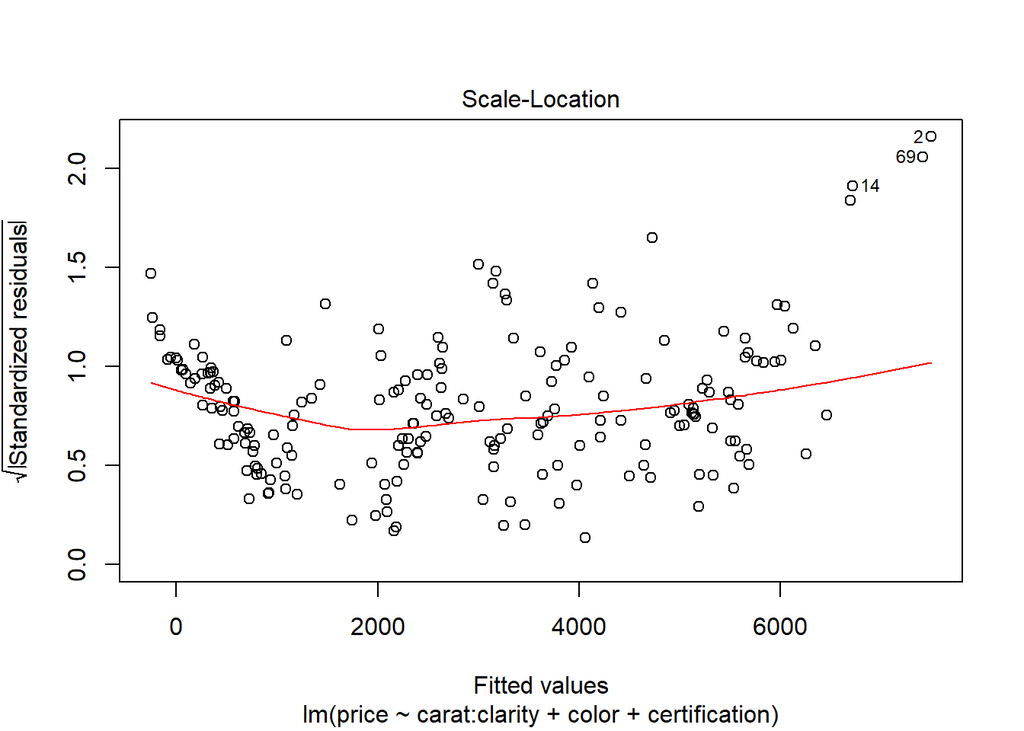

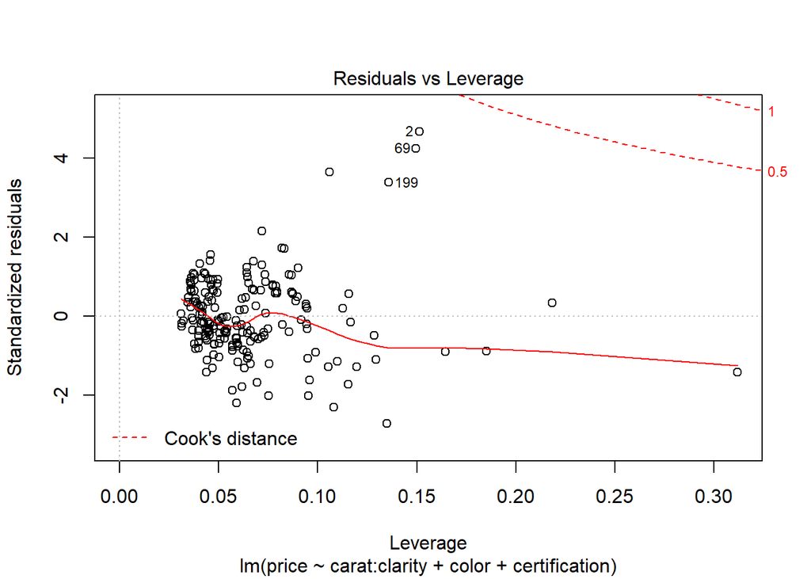

```r
require(car)
plot(revised_model)
```

```r
vif(revised_model)
```

```
##                   GVIF Df GVIF^(1/(2*Df))
## color         1.268004  5        1.024029
## certification 2.088340  2        1.202127
## carat:clarity 2.277562  5        1.085793
```

att a nonlinear term to something(carat maybe)

from here going to use boxCox to try and determine a way to normalize our price response, since the response data looks very exponential . The lambda value suggested was .41 . VIF for the transformed non-linear model looks good, all values are under 5 which tells us that collinearity is not at play. This is the final model!

```r
require(MASS)
require(car)
data=boxcox(revised_model,lambda=seq(-2,2,1/100))
```

[figure not shown]

```r
data$x[which(data$y==max(data$y))]
```

```
## [1] 0.41
```

```r
#transformed data

non_linmodel=lm(price^(.41)~ color+certification+carat:clarity, contrasts = list(color = contr.treatment(n = 6, base =6)), data=diamonds)
summary(non_linmodel)
```

```
##
## Call:
## lm(formula = price^(0.41) ~ color + certification + carat:clarity,
##     data = diamonds, contrasts = list(color = contr.treatment(n = 6,
##         base = 6)))
##
## Residuals:
##      Min       1Q   Median       3Q      Max
## -2.75475 -0.40393  0.00668  0.48093  2.32910
##
## Coefficients:
##                   Estimate Std. Error t value Pr(>|t|)
## (Intercept)        4.41613    0.25258  17.484  < 2e-16 ***
## color1             5.42908    0.26835  20.232  < 2e-16 ***
## color2             3.97001    0.21101  18.814  < 2e-16 ***
## color3             3.14727    0.19434  16.195  < 2e-16 ***
## color4             2.33579    0.19602  11.916  < 2e-16 ***
## color5             1.42367    0.19643   7.248 1.08e-11 ***
## certificationHRD   0.10001    0.14598   0.685    0.494
## certificationIGI  -0.03726    0.15737  -0.237    0.813
## carat:clarityIF   31.51637    0.47106  66.905  < 2e-16 ***
## carat:clarityVS1  27.54400    0.28257  97.477  < 2e-16 ***
## carat:clarityVS2  26.66590    0.28444  93.748  < 2e-16 ***
## carat:clarityVVS1 30.06276    0.31245  96.217  < 2e-16 ***
## carat:clarityVVS2 28.39090    0.28247 100.508  < 2e-16 ***
## ---
## Signif. codes:  0 '***' 0.001 '**' 0.01 '*' 0.05 '.' 0.1 ' ' 1
##
## Residual standard error: 0.7501 on 187 degrees of freedom
## Multiple R-squared:  0.9915, Adjusted R-squared:  0.9909
## F-statistic:  1815 on 12 and 187 DF,  p-value: < 2.2e-16
```

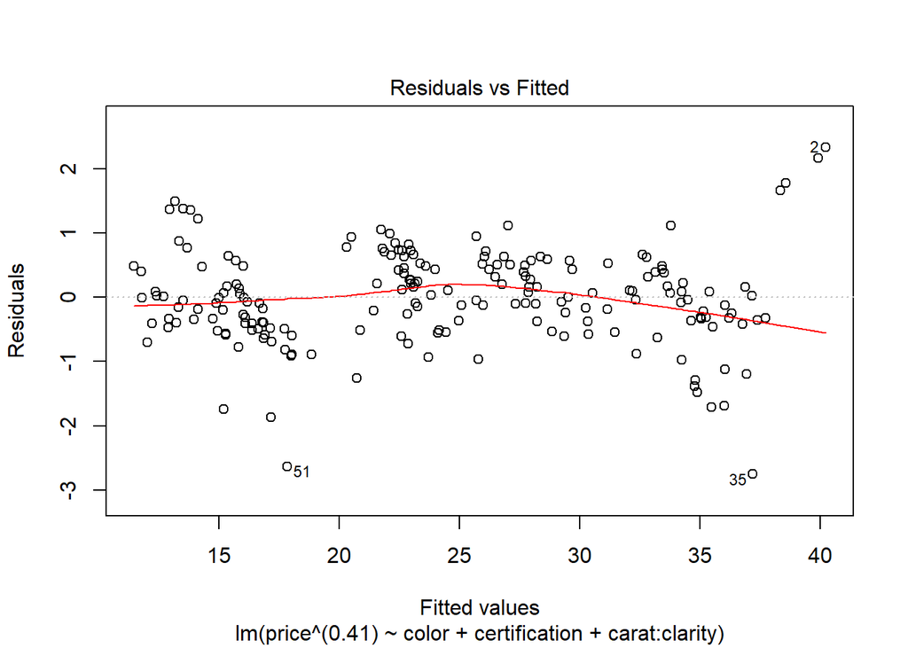

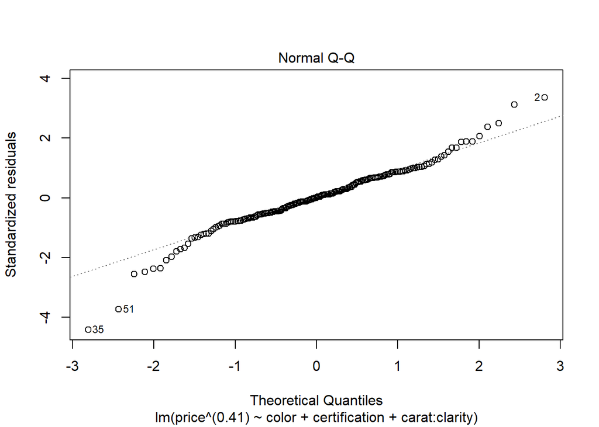

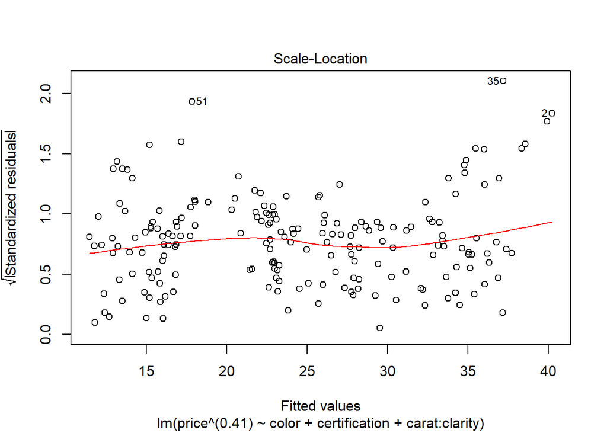

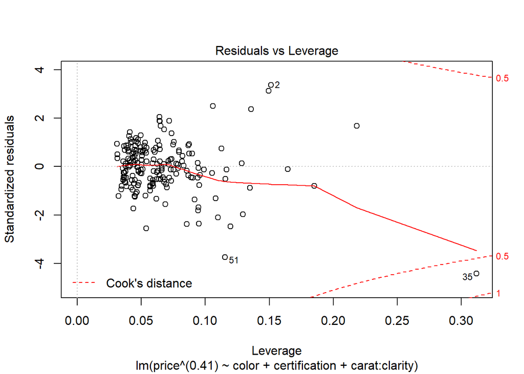

```r
plot(non_linmodel)
```

```r
anova(non_linmodel)
```

```
## Analysis of Variance Table
##
## Response: price^(0.41)
##                Df Sum Sq Mean Sq F value    Pr(>F)
## color           5  697.7  139.54  247.98 < 2.2e-16 ***
## certification   2 4370.0 2184.98 3883.03 < 2.2e-16 ***
## carat:clarity   5 7187.6 1437.52 2554.67 < 2.2e-16 ***
## Residuals     187  105.2    0.56
## ---
## Signif. codes:  0 '***' 0.001 '**' 0.01 '*' 0.05 '.' 0.1 ' ' 1
```

```r
vif(non_linmodel)
```

```
##                   GVIF Df GVIF^(1/(2*Df))
## color         1.268004  5        1.024029
## certification 2.088340  2        1.202127
## carat:clarity 2.277562  5        1.085793
```